# FARMR!SK automatic report

The main pathways of disease entry are: **Animal transport** and **Animals from other origin**.

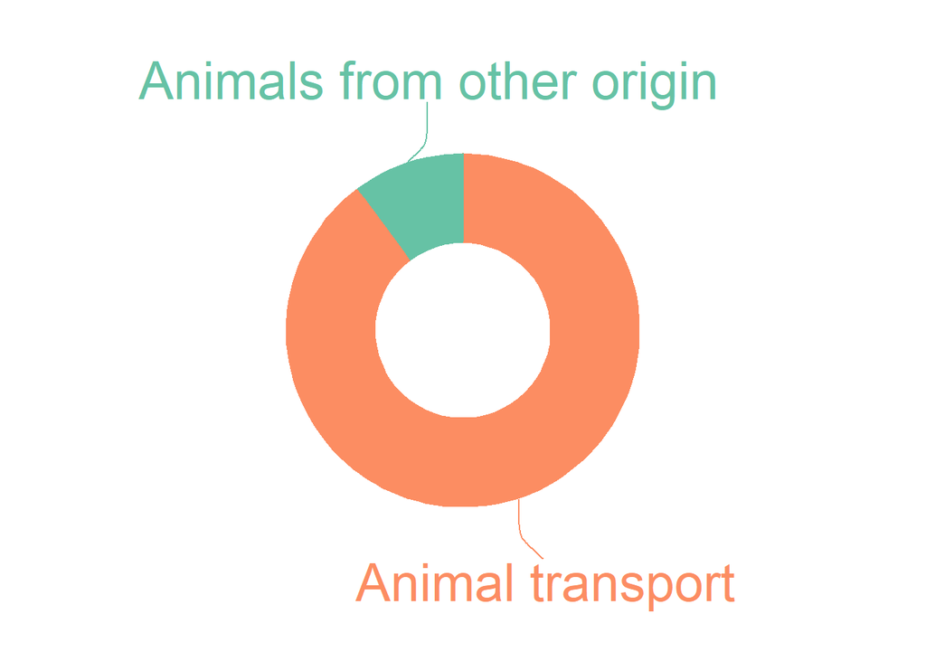

(a) IBR

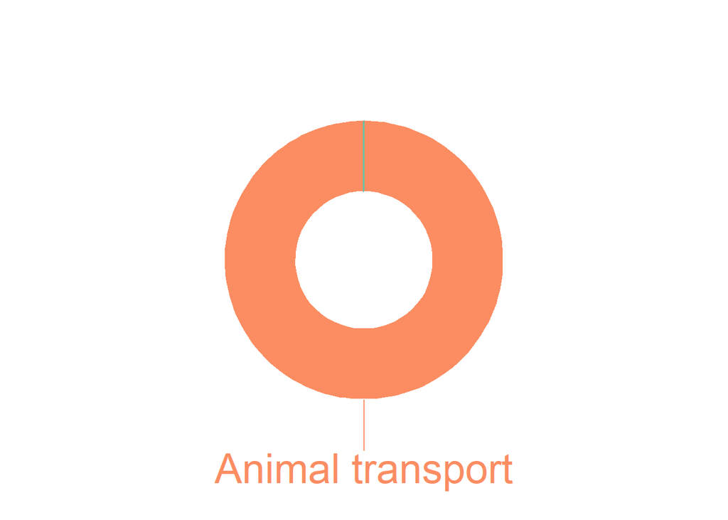

(b) BVD

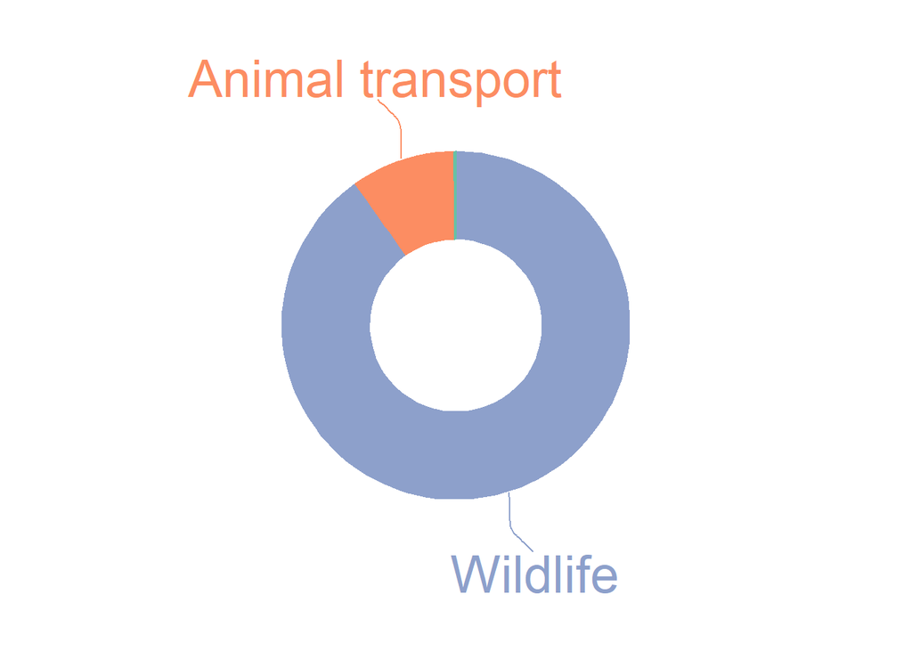

(c) TB

Figure 1.2: Risk of disease entry by pathway

## **Infectious Bovine Rhinotracheitis (IBR)**

### Current risk

Annual risk of IBR entry in the farm: **0.593%** (0.41-0.786%)

By pathway:

- Animal transport: **0.531%** (0.357-0.689%)
- Animals from other origin: **0.0598%** (0.00604-0.182%)

### Risk reduction of biosecurity measures

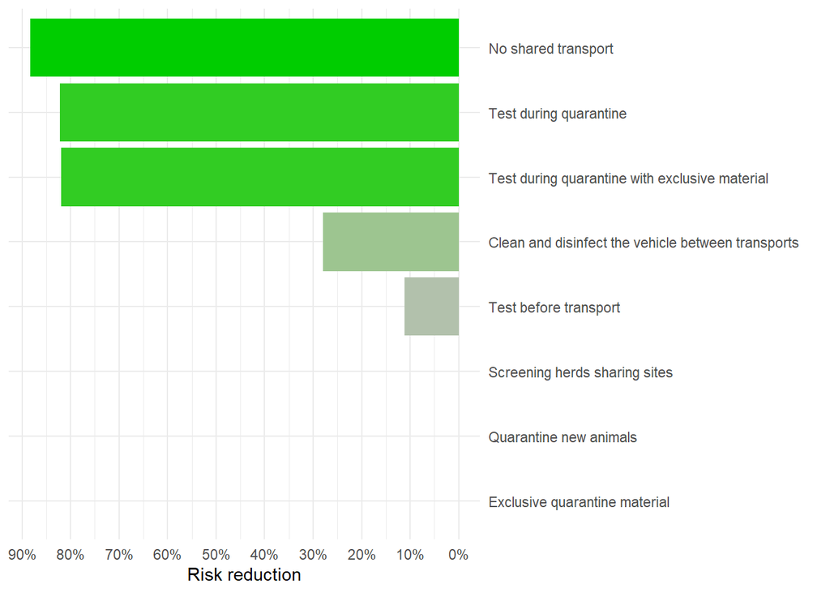

## **Bovine viral diarrhea (BVD)**

### Current risk

Annual risk of BVD entry in the farm: **8.33%** (4.82-11.6%)

By pathway:

- Animal transport: **8.33%** (4.82-11.6%)
- Animals from other origin: **0.00463%** (0.000782-0.0158%)

### Risk reduction of biosecurity measures

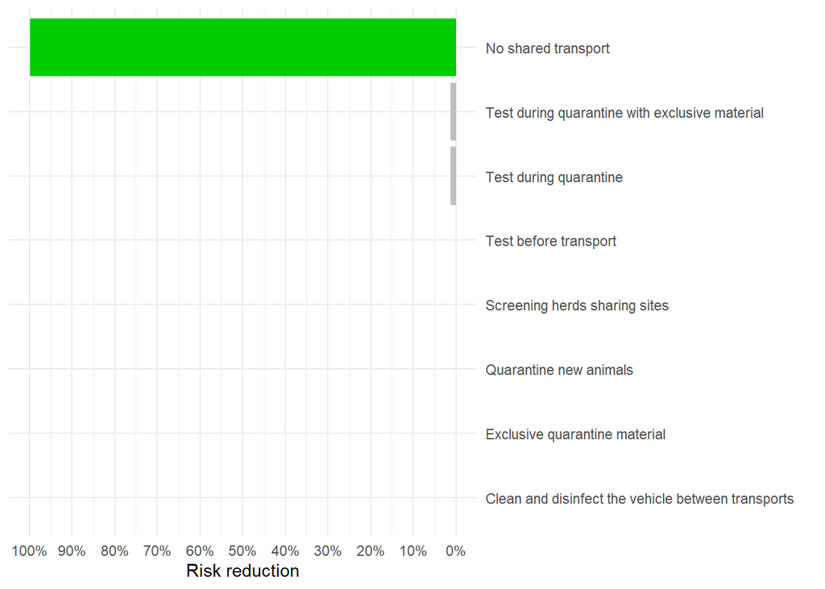

## **Bovine Tuberculosis (TB)**

### Current risk

Annual risk of TB entry in the farm: **0.0316%** (0.00721-0.109%)

By pathway:

- Wildlife: **0.0285%** (0.00369-0.106%)
- Animal transport: **0.00306%** (0.00228-0.00408%)
- Animals from other origin: **4.75e-05%** (3.21e-05-6.41e-05%)

### Risk reduction of biosecurity measures

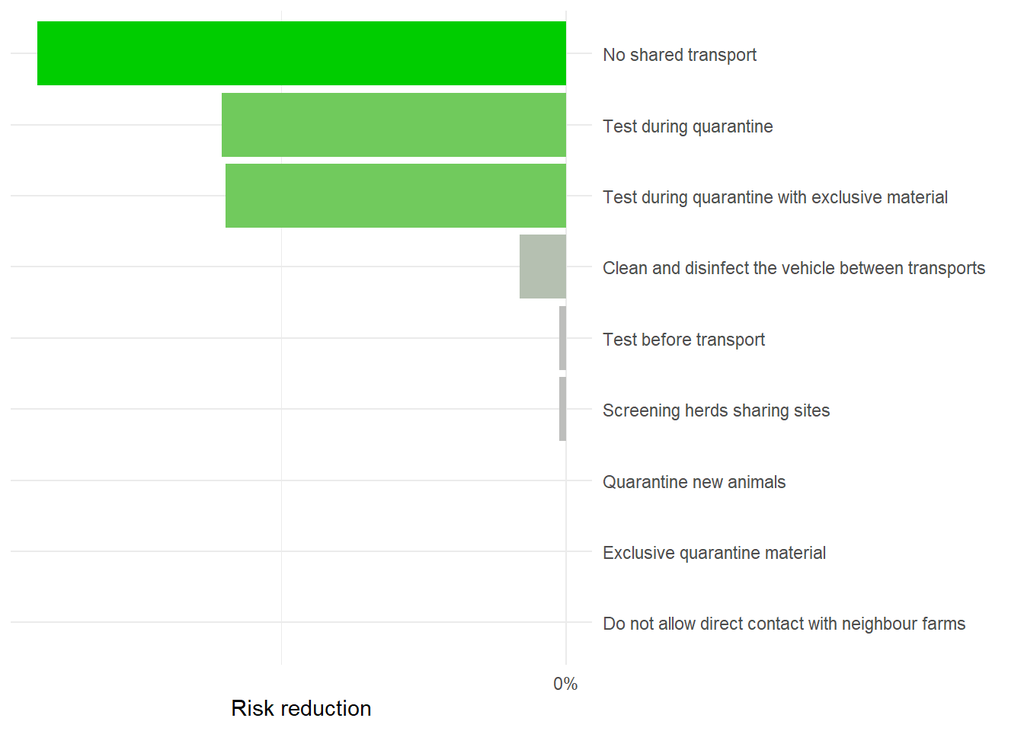

# 🐄 Description of the farm

## Farm information

**Location:** Cataluña, Spain

**Farm type:** Dairy cattle, NA

**Cattle cens:**

- 35 Calves ( <8 m)
- 10 Heifers (8 - 24 m)
- 24 Adult cows (>24 m)
- 1 Bulls

**Other animals in the farm:**

- **Direct contact with cattle:** 3 dogs, 18 cats
- **No direct contact with cattle:** 200 sheep, 100 pigs

**Neighbours**: No cattle farms within a 1-2km radious (negligible risk)

## Farm vehicles

*The farm does not have its own vehicles for animal transport.*

## Visits

### People entering the barn

*No people entering the barn or contacting the animals*

### Vehicles entering the farm perimeter

*No vehicles entering the farm perimeter*

# 🚚 Movements

Animal movements in the last 12 months

| mov_id | When | Origin | Animals moved | Shared site | Vehicle used | Risk |
| --- | --- | --- | --- | --- | --- | --- |
| recurrente_recria | 🔁 Recurrent round: 1.25 times/year, out for 500 days | Other farm/s: Barcelona | 3 Heifers (8 - 24 m) | No | Own NA and External (shared journey) | IBR: 0.51%, BVD: 8.22%, TB: 0.00192% |
| terneros_austria | ➡️ One-off entry: 2024-05-01 | Other farm/s: Austria | 4 Calves ( <8 m) | - | External (shared journey) | IBR: 0.0418%, BVD: 0.0541%, TB: 0.000618% |
| recurrente_machos | ➡️ Recurrent entry: 1.25 times/year | Genetic selection centre: Austria | 3 Calves ( <8 m) | - | External (shared journey) | IBR: 0.0297%, BVD: 0.0523%, TB: 0.000569% |

### Health status and tests in origin

| mov_id | Pathogen | Health status in origin | Test in origin |
| --- | --- | --- | --- |
| recurrente_machos | BVD | Unknown | - |
|  | IBR |  |  |
|  | TB |  |  |
| recurrente_recria | BVD |  |  |
|  | IBR |  |  |
|  | TB |  |  |
| terneros_austria | BVD |  |  |
|  | IBR |  |  |
|  | TB |  |  |

### Quarantine

#### Characteristics

*No quarantine*

# 🐗 Wildlife

**Wildlife:** IBR: -, BVD: -, TB: 0.0285%

- Outdoors grazing: Outdoors grazing, no complete perimeter fence (electric) (IBR: -, BVD: -, TB: 0.0285%)
- Pasture (trashumance): No pastures

### Farm water points

| Waterpoints | Mud |
| --- | --- |
| 100% High waterer (>90cm) | 0% |
| 100% Waterhole | 100% |

### Pasture water points

*No pasture water points*

# Comments

- 25 vedells propis que engreixa a la seva granja (fins a 1 any) (complete)
- recurrente_recria: Numero animals aproximat (complete)
- recurrente_machos: A confirmar estatus i tests. (complete)